# enrollment_hawaii_students

```python
# import libraries

import numpy as np
import pandas as pd
import matplotlib.pyplot as plt

import warnings

# Suppress FutureWarnings
warnings.simplefilter(action='ignore', category=FutureWarning)
```

#### Read the CSV file and display the data

Once we've imported and converted our data into a dataframe, the next step involves data cleaning. This includes renaming the "SPRADDR_ZIP_PR" column to "ZIP" and the "IRO_INSTITUTION_DESCL" column to "INSTITUTION." Additionally, any rows with missing values in the "HAWAIIAN_LEGACY" column are assigned the value "NO."

```python
enrollment_df = pd.read_csv('enrollmentzipcode.csv')
```

```python
print("Shape: {} (row) x {} (col)".format(enrollment_df.shape[0], enrollment_df.shape[1]))
enrollment_df.head()
```

```
Shape: 159268 (row) x 5 (col)
```

|  | SEMESTER | SPRADDR_ZIP_PR | IRO_INSTITUTION_DESCL | HAWAIIAN_LEGACY | ENROLLMENT |
| --- | --- | --- | --- | --- | --- |
| 0 | Fall 2012 | 96706 | Honolulu Community College | NaN | 24 |
| 1 | Fall 2012 | 96826 | Kapi`olani Community College | NaN | 5 |
| 2 | Fall 2012 | 96734 | Windward Community College | NaN | 205 |
| 3 | Fall 2012 | 96797 | Leeward Community College | NaN | 517 |
| 4 | Fall 2012 | 96712 | University of Hawai`i at Manoa | NaN | 37 |

```python
# rename columns and change NaN Hawaiian Legacy rows to NO
enrollment_df = enrollment_df.rename(columns={"SPRADDR_ZIP_PR": "ZIP", "IRO_INSTITUTION_DESCL": "INSTITUTION"})
enrollment_df = enrollment_df.fillna('NO')
```

## 1. Enrollment over the years

- Is this the best way to present this data? Is it easy to see the trends when the data is shown this way?
- Is this a complete view of the data? The Covid-19 epidemic may have been disruptive and we should look at data for every year in the 2012-2022 period.
- Should we use a bar chart? If not, what else? If yes, which variant (grouped, stacked, etc.?
- What aesthetic elements can improve the visualization?

Address the following points in you computational notebook (or equivalent):

1. Wrangel the data so you have enrollment counts for every year between 2012-2022 for Manoa and another institution of your choice (you can choose to add more of the UH institutions)
2. Use a markdown cell to explain your approach to wrangling the data.
3. Create a visualization that shows the enrollment trends for the 2 institutions over the years.
4. Use a markdown cell to explain your design choices.
5. Use a markdown cell to describe the trends you see.

#### 1.1 Data Wrangling

To create graphs depicting enrollment numbers for each year and institution, it makes sense to group the data by `SEMESTER` and `INSTITUTION`, and subsequently aggregate the `ENROLLMENT` values by summing them.

```python
# Aggregate data for duplicate entries by summing the enrollments
enrollment_year_inst = enrollment_df.groupby(['SEMESTER', 'INSTITUTION']).agg({'ENROLLMENT': 'sum'}).reset_index()
enrollment_year_inst.head()
```

|  | SEMESTER | INSTITUTION | ENROLLMENT |
| --- | --- | --- | --- |
| 0 | Fall 2012 | Hawai`i Community College | 3663 |
| 1 | Fall 2012 | Honolulu Community College | 4582 |
| 2 | Fall 2012 | Kapi`olani Community College | 8892 |
| 3 | Fall 2012 | Kaua`i Community College | 1495 |
| 4 | Fall 2012 | Leeward Community College | 7960 |

```python
# Pivot the data after removing duplicates
pivot_df = enrollment_year_inst.pivot(index='SEMESTER', columns='INSTITUTION', values='ENROLLMENT')

# Extract the semesters, institutions, and data for the bars
semesters = pivot_df.index
institutions = pivot_df.columns
data = pivot_df.values
```

#### 1.2 Plot Student Enrollment by Semester and Institution

**Design Choices**

For this task, I have chosen to create a grouped bar chart to visualize Student Enrollment by Semester and Institution over multiple semesters. Here are the design choices that led me to select this type of chart:

- Grouped Bar Chart: I opted for a grouped bar chart because it is well-suited for comparing data across multiple categories (institutions) over time (semesters). Each inst-itution will have its own set of bars, making it easy to see how enrollment levels change for each one.
- Color Differentiation: I used different colors for each institution's bars in the chart. This color differentiation makes it visually clear which bars correspond to which institution, enhancing readability and aiding in trend identification.
- Labels: I included labels for both the x-axis (semesters) and the y-axis (enrollment). This ensures that viewers can easily understand the data and its context without needing additional information.

**Trends Identified**

Analyzing the grouped bar chart, several trends become apparent:

In summary, the grouped bar chart effectively highlights enrollment trends across different institutions and semesters, making it easier to identify patterns and draw insights from the data.

##### 1.2.1 Grouped Bar Chart

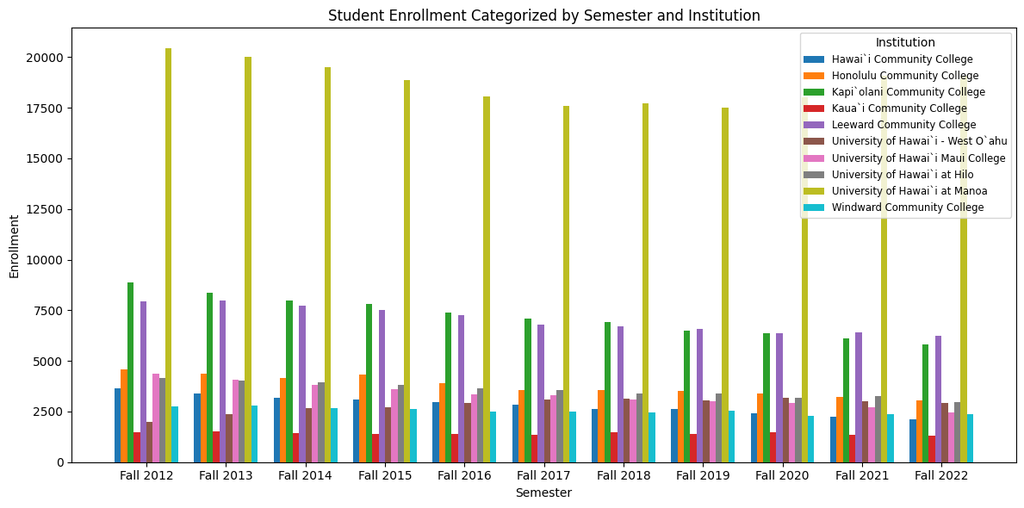

```python
# Set the bar width and positions for each bar group
bar_width = 0.08
bar_positions = np.arange(len(semesters))

# Create grouped bar plot
fig, ax = plt.subplots(figsize=(12, 6))
for i, institution in enumerate(institutions):
    ax.bar(bar_positions + i * bar_width, data[:, i], bar_width, label=institution)

ax.set_xlabel('Semester')
ax.set_ylabel('Enrollment')
ax.set_title('Student Enrollment Categorized by Semester and Institution')
ax.set_xticks(bar_positions + (len(institutions) - 1) * bar_width / 2)
ax.set_xticklabels(semesters)
ax.legend(title='Institution',  loc='upper right', fontsize='small')

plt.tight_layout()
plt.show()
```

##### 1.2.2 Line Plot

In this scenario, a line plot appears to be an effective choice as well due to its ability to utilize distinct colors for each institution, making it simple to distinguish between them and facilitating straightforward comparisons.

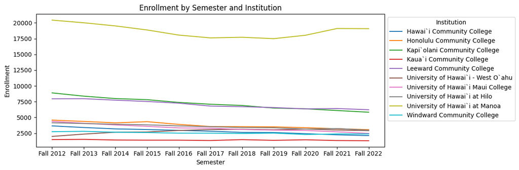

```python
# Create a line plot for each institution
plt.figure(figsize=(12, 4))

for i, institution in enumerate(institutions):
    plt.plot(semesters, data[:, i], label=institution)

plt.xlabel('Semester')
plt.ylabel('Enrollment')
plt.title('Enrollment by Semester and Institution')
plt.legend(title='Institution', bbox_to_anchor=(1, 1))

plt.tight_layout()
plt.show()
```

## 2. Enrollment of Hawaiian students

Our dataset also includes data regarding the Hawaiian legacy of the enrolled students. How should we visualize the proportion of enrolled students of Hawaiian legacy out of the whole student body enrollment? Address the following points in you computational notebook (or equivalent):

1. Wrangel the data so you have enrollment counts of the students with Hawaiian legacy aggregated over the full time period available in the data divided to the same UH institutions you chose in the previous section. Find the count of enrolled students not of Hawaiian legacy.
2. Use a markdown cell to explain your approach to wrangling the data.
3. Create a visualization that shows the proportion of Hawaiian students in the chosen institution.
4. Use a markdown cell to explain your design choices.
5. Use a markdown cell to describe the results. Are they surprising? You can use as many cells as you wish for data wrangling and visualization, just make sure your notebook has textual breaks (markdown cells) that make the organization of the notebook clear.

#### 2.1 The Proportions of Hawaiian Legacy for All Institutions.

**Design Choices** For this task, we have chosen to create a bar chart that groups data by institution and focuses on the legacy status of students. Here's an explanation of our design choices:

- Bar Chart: We selected a bar chart as the visualization method because it is effective in comparing categorical data, in this case, the ratio of students with and without Hawaiian legacy, across different institutions.

It's important to note that while the chart illustrates the ratio of students with Hawaiian legacy, it does not provide specific enrollment numbers for each semester.

##### 2.1.1 Data Wrangling

```python
# Group the data by institution and Hawaiian legacy status
grouped_inst_legacy = enrollment_df.groupby(['INSTITUTION', 'HAWAIIAN_LEGACY'])['ENROLLMENT'].sum().unstack(fill_value=0)
grouped_inst_legacy.head()
```

| HAWAIIAN_LEGACY INSTITUTION | HAWAIIAN | NO |
| --- | --- | --- |
| Hawai`i Community College | 13927 | 17242 |
| Honolulu Community College | 11156 | 30440 |
| Kapi`olani Community College | 14798 | 64441 |
| Kaua`i Community College | 5088 | 10480 |
| Leeward Community College | 21724 | 55830 |

##### 2.1.1 Bar Chart

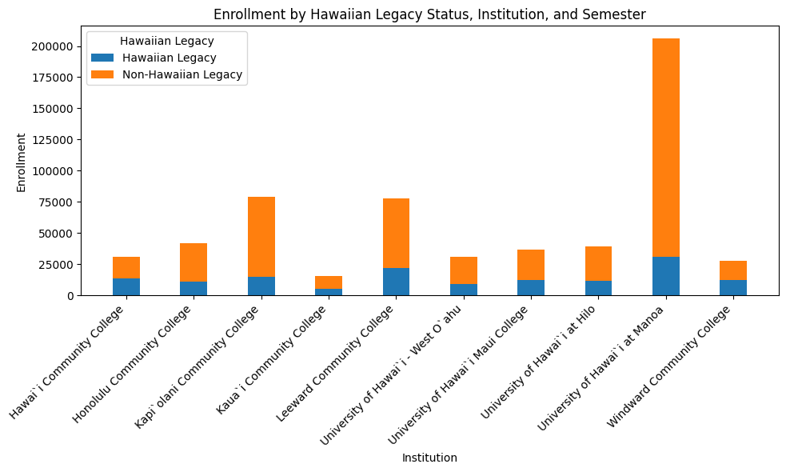

```python
# Create a bar plot to visualize the proportions for all institutions
fig, ax = plt.subplots(figsize=(10, 6))
width = 0.4

bar1 = ax.bar(grouped_inst_legacy.index, grouped_inst_legacy['HAWAIIAN'], width, label='Hawaiian Legacy')
bar2 = ax.bar(grouped_inst_legacy.index, grouped_inst_legacy['NO'], width, bottom=grouped_inst_legacy['HAWAIIAN'], label='Non-Hawaiian Legacy')

# set the y and x labels
ax.set_xlabel('Institution')
ax.set_ylabel('Enrollment')
ax.set_title('Enrollment by Hawaiian Legacy Status, Institution, and Semester')
ax.legend(title='Hawaiian Legacy')

plt.xticks(rotation=45, ha="right")  # Rotate x-axis labels for better readability
plt.tight_layout()
plt.show()
```

#### 2.2 Hawaiian Legacy Proportions for UH Manoa and Hilo Over the Years.

In order to display all the semesters clearly, we opted to limit the number of institutions to two. The colors at the bottom of the chart represent the count of Hawaiian legacy students. Our observations reveal that the count of legacy students remains relatively consistent over the years, while the count of non-Hawaiian legacy students exhibits fluctuations.

##### 2.2.1 Data Wrangling

Since we only want to create graphs for two institutions, we filter based on the institution names. The dataframe is grouped by `SEMESTER` and `INSTITUTION`, with the aggregated values of `ENROLLMENT` and whether the students contain the Hawaiian Legacy.

```python
selected_institutions = ['University of Hawai`i at Manoa', 'University of Hawai`i at Hilo']
filtered_df = enrollment_df[enrollment_df['INSTITUTION'].isin(selected_institutions)]

# Pivot the filtered data
pivot_df = filtered_df.pivot_table(index=['SEMESTER', 'INSTITUTION'], columns='HAWAIIAN_LEGACY', values='ENROLLMENT', aggfunc='sum', fill_value=0)


# Extract semesters and institutions
semesters = pivot_df.index.get_level_values('SEMESTER').unique()
institutions = pivot_df.index.get_level_values('INSTITUTION').unique()
```

##### 2.2.2 Grouped Bar Chart

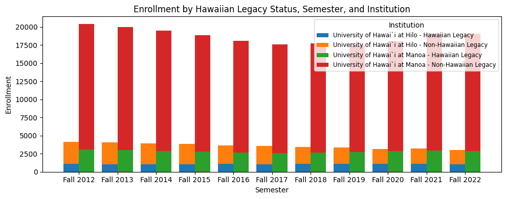

```python
# Set the width of the bars and the positions
bar_width = 0.4
bar_positions = np.arange(len(semesters))

# Create a grouped bar plot
fig, ax = plt.subplots(figsize=(10, 4))

for i, institution in enumerate(institutions):
    hawaiian_legacy = pivot_df.loc[pivot_df.index.get_level_values('INSTITUTION') == institution, 'HAWAIIAN'].values
    non_hawaiian_legacy = pivot_df.loc[pivot_df.index.get_level_values('INSTITUTION') == institution, 'NO'].values

    # plot th 2 bars for each institution with hawaiian legacy being at the bottom
    ax.bar(bar_positions + i * bar_width, hawaiian_legacy, bar_width, label=f'{institution} - Hawaiian Legacy')
    ax.bar(bar_positions + i * bar_width, non_hawaiian_legacy, bar_width, label=f'{institution} - Non-Hawaiian Legacy', bottom=hawaiian_legacy)

# set the x and y labels
ax.set_xlabel('Semester')
ax.set_ylabel('Enrollment')
ax.set_title('Enrollment by Hawaiian Legacy Status, Semester, and Institution')
ax.set_xticks(bar_positions + bar_width * (len(institutions) - 1) / 2)
ax.set_xticklabels(semesters)
ax.legend(title='Institution', fontsize='small', loc='upper right')

plt.tight_layout()
plt.show()
```

#### 2.3 Enrollment by Hawaiian Legacy for Each Institution

Now, to gain a clearer understanding of the results for all institutions over the years, we have created a separate graph for each institution. These graphs are in the form of line charts, which prove to be more effective than bar charts when visualizing small changes that might not be easily discernible. As mentioned earlier, the two institutions mentioned earlier exhibit relatively stable enrollment numbers for Hawaiian legacy students. However, when examining other institutions, it becomes evident that the number of Hawaiian legacy students enrolled has undergone significant fluctuations over the years. Consequently, these line charts provide a more precise illustration of the ratio of Hawaiian legacy students to total enrollment over time, while the bar chart remains valuable for comparing differences between institutions.

##### 2.3.1 Data Wranagling

Similar as above, the dataframe is grouped by `SEMESTER` and `INSTITUTION`, with the aggregated values of `ENROLLMENT` and whether the students contain the Hawaiian Legacy.

```python
# Pivot the filtered data
pivot_df = enrollment_df.pivot_table(index=['SEMESTER', 'INSTITUTION'], columns='HAWAIIAN_LEGACY', values='ENROLLMENT', aggfunc='sum', fill_value=0)

# Extract semesters and institutions
semesters = pivot_df.index.get_level_values('SEMESTER').unique()
institutions = pivot_df.index.get_level_values('INSTITUTION').unique()
```

##### 2.3.2 Line Plot

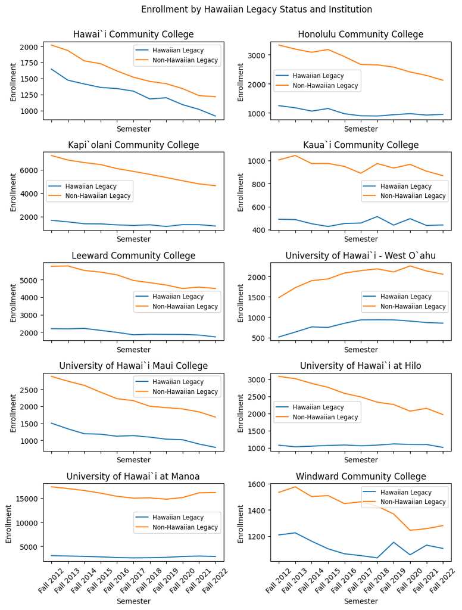

```python
# Calculate the number of rows and columns for the subplots
num_plots = len(institutions)
num_cols = 2  # Change this to the desired number of columns
num_rows = (num_plots - 1) // num_cols + 1  # Calculate the number of rows needed

# Set up the figure with the desired number of columns and adjusted figsize
fig, axs = plt.subplots(num_rows, num_cols, figsize=(10, 3 * num_rows), sharex=True)

# Flatten the 2D axs array into a 1D array
axs = axs.flatten()

# Create a line plot for each institution
for i, institution in enumerate(institutions):
    hawaiian_legacy = pivot_df.loc[pivot_df.index.get_level_values('INSTITUTION') == institution, 'HAWAIIAN'].values
    non_hawaiian_legacy = pivot_df.loc[pivot_df.index.get_level_values('INSTITUTION') == institution, 'NO'].values


    axs[i].plot(semesters, hawaiian_legacy, label='Hawaiian Legacy')
    axs[i].plot(semesters, non_hawaiian_legacy, label='Non-Hawaiian Legacy')
    axs[i].set_ylabel('Enrollment', fontsize=10)
    axs[i].set_xlabel('Semester', fontsize=10)
    axs[i].set_xticks(np.arange(len(semesters)))
    axs[i].set_xticklabels(semesters, rotation=45, fontsize=10)
    axs[i].set_title(institution)
    axs[i].legend(fontsize='small')


# Set overall title for all subplots
fig.suptitle('Enrollment by Hawaiian Legacy Status and Institution', fontsize=12)
# Adjust rect for suptitle
plt.tight_layout(rect=[0, 0.2, 0.9, 0.98])
plt.show()
```